# Weather Impact Analisys

## Scaling

It can be seen that some exponents were not acurately specified (“?”,“+”,“-”). There are considered to be 0.

```r
levels(storm$CROPDMGEXP)
```

```
## [1] ""  "?" "0" "2" "B" "k" "K" "m" "M"
```

```r
levels(storm$PROPDMGEXP)
```

```
##  [1] ""  "-" "?" "+" "0" "1" "2" "3" "4" "5" "6" "7" "8" "B" "h" "H" "K"
## [18] "m" "M"
```

These scales are applied in order to obtain the top events impacts based on FATALITIES, TOTAL PROPERTY DAMAGE defined as the sum of CROP DAMAGE and PROPERTY DAMAGE and the number of AFFECTED PEOPLE defined as the sum of the number of FATALITIES and the number of people with INJURIES. Each quantity is grouped by each event:

```r
library(data.table)
storm$CROPDMG=ApplyScale(storm$CROPDMGEXP,storm$CROPDMG)
storm$PROPDMG=ApplyScale(storm$PROPDMGEXP,storm$PROPDMG)
TotalStorm=storm[,.(FATALITIES=sum(FATALITIES),INJURIES=sum(INJURIES),CROP_DAMAGE=sum(CROPDMG),PROPERTY_DAMAGE=sum(PROPDMG)),by=EVTYPE]
total=getTop("TOTAL",TotalStorm,T,5)
totalv=getTopValues("TOTAL",TotalStorm,5)
total
```

```
##    SOURCE TOTAL_PROPERTY_DAMAGE AFFECTED_PEOPLE FATALITIES
## 1:  TOTAL                 FLOOD         TORNADO    TORNADO
## 2:  TOTAL     HURRICANE|TYPHOON            WIND       HEAT
## 3:  TOTAL                 STORM            HEAT      FLOOD
## 4:  TOTAL               TORNADO           FLOOD       WIND
## 5:  TOTAL                  WIND       LIGHTNING  LIGHTNING
```

```r
totalv
```

```
##    SOURCE TOTAL_PROPERTY_DAMAGE AFFECTED_PEOPLE FATALITIES
## 1:  TOTAL          180528894734           96997       5633
## 2:  TOTAL           90762452810           12831       3132
## 3:  TOTAL           57843187100           12343       1557
## 4:  TOTAL           57367113946           10238       1410
## 5:  TOTAL           20102055572            6049        817
```

At first glance it seems that the FLOOD is the main cause of property damage and TORNADO has the main effect on peoples health.

To make sure that this analysis is realiable we visually explore the distribuition of those events on each year:

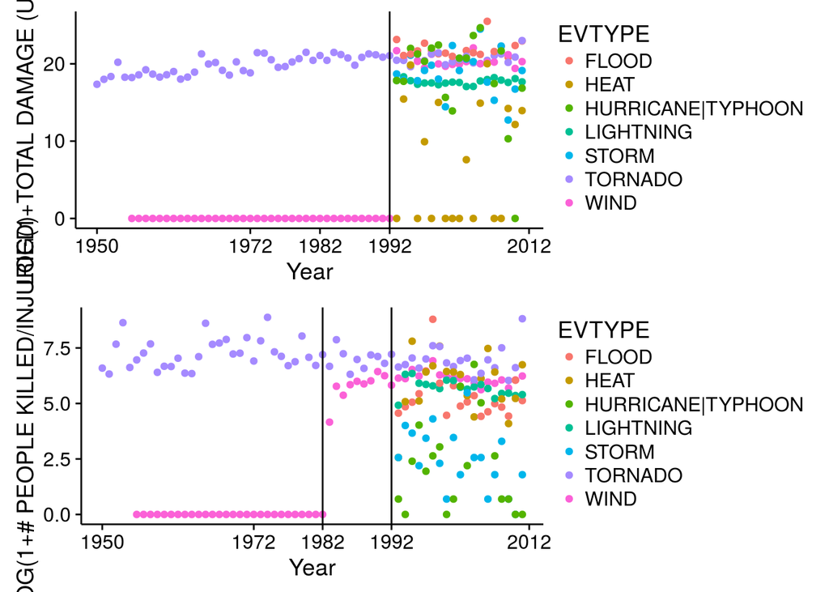

```r
library(cowplot)
source("scale.R")
storm$Year=year(as.Date(gsub(" .*","",as.character(storm$BGN_DATE)),format="%m/%d/%Y"))
TotalStormYear=storm[,.(FATALITIES=sum(FATALITIES),INJURIES=sum(INJURIES),CROP_DAMAGE=sum(CROPDMG),PROPERTY_DAMAGE=sum(PROPDMG)),by=.(EVTYPE,Year)]
TotalStormYear[,TOTAL_DAMAGE:=CROP_DAMAGE+PROPERTY_DAMAGE]
TotalStormYear[,TOTAL_HEALTH_DAMAGE:= FATALITIES+INJURIES]

events=unique(as.array(as.matrix(total[,-1,with=FALSE]))[1:15])
datas=c("1950","1972","1982", "1992","2012")
ndatas=as.numeric(datas)

plot_dmg=ggplot(data=TotalStormYear[EVTYPE %in% events],aes(x=Year,y=log(1+TOTAL_DAMAGE),colour=EVTYPE))+geom_point()+ylab("LOG(1+TOTAL DAMAGE (US$))")+scale_x_continuous(breaks=ndatas,labels=datas)+
        geom_vline(xintercept=1992)


plot_health=ggplot(data=TotalStormYear[EVTYPE %in% events],aes(x=Year,y=log(1+TOTAL_HEALTH_DAMAGE),colour=EVTYPE))+geom_point()+scale_x_continuous(breaks=ndatas,labels=datas)+geom_vline(xintercept=1982)+geom_vline(xintercept=1992)+ylab("LOG(1+# PEOPLE KILLED/INJURIED)")

multiplot(plot_dmg,plot_health)
```

```r
#plot_grid(plot_dmg, plot_health, labels=c("Economic Impact/Year", "Health Impact/Year"), ncol = 2, nrow = 1)
```

```r
TotalStorm93=storm[Year >1992,.(FATALITIES=sum(FATALITIES),INJURIES=sum(INJURIES),CROP_DAMAGE=sum(CROPDMG),PROPERTY_DAMAGE=sum(PROPDMG)),by=EVTYPE]
post92=getTop("POST 92 TOTAL",TotalStorm93,T,5)
post92v=getTopValues("POST 92 TOTAL",TotalStorm93,5)


post92
```

```
##           SOURCE TOTAL_PROPERTY_DAMAGE AFFECTED_PEOPLE FATALITIES
## 1: POST 92 TOTAL                 FLOOD         TORNADO       HEAT
## 2: POST 92 TOTAL     HURRICANE|TYPHOON            HEAT    TORNADO
## 3: POST 92 TOTAL                 STORM           FLOOD      FLOOD
## 4: POST 92 TOTAL               TORNADO            WIND       WIND
## 5: POST 92 TOTAL                  WIND       LIGHTNING  LIGHTNING
```

```r
post92v
```

```
##           SOURCE TOTAL_PROPERTY_DAMAGE AFFECTED_PEOPLE FATALITIES
## 1: POST 92 TOTAL          180528894734           24949       3132
## 2: POST 92 TOTAL           90762452810           12343       1621
## 3: POST 92 TOTAL           57843187100           10238       1557
## 4: POST 92 TOTAL           26768915376            9242       1147
## 5: POST 92 TOTAL           20102055572            6049        817
```

Now it appears that HEAT is the main cause of fatalities. In these analysis we failed to account for population growth and inflation. To consider this impact a

[figure not shown]

and a

[figure not shown]

table are obtained for this purpose.

# Results

```r
#Account for inflation
rate=data.table(read.csv("inflation.rates.csv",header = T,sep=";"))
aux=1
rate=rate[which(with(rate,Year>1992 & Year < 2012))]
for(i in (length(rate$Year)-1):1){
        print(rate[i,]$Year)
        aux=aux*(1+as.numeric(as.character(rate[i+1,]$Ave))/100)
        rate$Acum[i]=aux
}
```

```
## [1] 2010
```

```
## [1] 2009
## [1] 2008
## [1] 2007
## [1] 2006
## [1] 2005
## [1] 2004
## [1] 2003
## [1] 2002
## [1] 2001
## [1] 2000
## [1] 1999
## [1] 1998
## [1] 1997
## [1] 1996
## [1] 1995
## [1] 1994
## [1] 1993
```

```r
rate$Acum[length(rate$Year)]=1
rate=rate[,c(1,15),with=F]
economic=storm[Year >1992,.(TOTAL_PROPERTY_DAMAGE=sum(CROPDMG+PROPDMG)),by=.(EVTYPE,Year)]
economic.impact=merge(economic,rate,by="Year",all=T)
economic.impact=economic.impact[,.(TOTAL_PROPERTY_DAMAGE=sum(TOTAL_PROPERTY_DAMAGE*Acum)),by=EVTYPE]
setorder(economic.impact,-TOTAL_PROPERTY_DAMAGE)
ei=melt(head(economic.impact,8),id.vars = "EVTYPE")
cacPalette=c("black","red","blue", "#CCCCFF","dark blue", "dark grey", "cyan", "yellow")
economic.plot=ggplot(data=ei,aes(x=variable ,y=value,fill=EVTYPE,order=value)) + geom_bar(stat="identity")+scale_fill_manual(values=cacPalette)+ylab("Acumulated Damages (values in US$ corrected to 2011)")+xlab("")+ggtitle("Total Acumulated Damage by Weather Event")
head(economic.plot,1)
```

```
## $data
##               EVTYPE              variable        value
## 1:             FLOOD TOTAL_PROPERTY_DAMAGE 210540670748
## 2: HURRICANE|TYPHOON TOTAL_PROPERTY_DAMAGE 108837373919
## 3:             STORM TOTAL_PROPERTY_DAMAGE  67438798647
## 4:           TORNADO TOTAL_PROPERTY_DAMAGE  31033961493
## 5:              COLD TOTAL_PROPERTY_DAMAGE  26678938868
## 6:              WIND TOTAL_PROPERTY_DAMAGE  25530919729
## 7:              HAIL TOTAL_PROPERTY_DAMAGE  22696922947
## 8:               DRY TOTAL_PROPERTY_DAMAGE  19067714328
```

```r
#Account for populational growth
growth=data.table(read.csv("population.csv",header =T,sep=";"))
growth=growth[which(with(growth,Year>1992 & Year < 2012))]
growth=growth[,c(1,2),with=F]
health=storm[Year >1992,.(MORTALITIES=sum(FATALITIES),MORBIDITIES=sum(FATALITIES+INJURIES)),by=.(EVTYPE,Year)]
health.impact=merge(health,growth,by="Year",all=T)
health.impact$MORTALITIES=health.impact$MORTALITIES*100000/health.impact$Population
health.impact$MORBIDITIES=health.impact$MORBIDITIES*100000/health.impact$Population
health.impact=health.impact[,.(MORTALITIES=mean(MORTALITIES,na.rm=T),
                               MORBIDITIES=mean(MORBIDITIES,na.rm=T)),by=EVTYPE]
setorder(health.impact,-MORTALITIES,-MORBIDITIES)
head(health.impact,1)
```

```
##    EVTYPE MORTALITIES MORBIDITIES
## 1:   HEAT  0.05894767   0.2289958
```

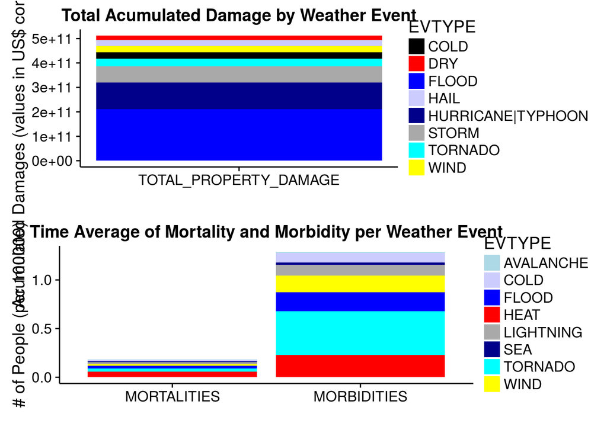

```r
hi=melt(head(health.impact,8),id.vars = "EVTYPE")
cbcPalette=c("light blue","#CCCCFF","blue","red", "dark grey","dark blue",  "cyan", "yellow")
health.plot=ggplot(data=hi,aes(x=variable ,y=value,fill=EVTYPE,order=value)) + geom_bar(stat="identity")+scale_fill_manual(values=cbcPalette)+ylab("# of People (per 100000)")+xlab("")+ggtitle("Time Average of Mortality and Morbidity per Weather Event")
#plot_grid(economic.plot, health.plot,ncol = 2, nrow = 1)
multiplot(economic.plot,health.plot)
```